# 2x2 Tables and Chi-Squared tests

# Categorical data analysis

For categorical data, there is an evaluation of the proportions of data rather than summaries such as means or medians. A contingency table can be used to display frequencies of events for two given categorical variables and can aid in determining probabilities of events.

Table 1: 2x2 contingency table

[output not shown]

Similarly, we can used a 2x2 table to inspect the accuracy of a dignostic test. By compared the stratifiying negative and positive test by true disease state we can caluclate the specificly the senseitvity, specifcity, positive predictive (PPV) and negative predictive values (NPV).

Table 2: 2x2 contingency table

|  |  | Disease Yes | Disease No | Totals |
| --- | --- | --- | --- | --- |
| Test | Yes | True Positive | False Positives | Number who test positive |
|  | No | False Negative | True negatives | Number who test negative |
|  | Totals | Number with disease | Number without disease | N |

Sensitivity = TP/(TP+FN), Specificity=TN/(FP+TN)  
Positive Predicitve Value=TP/(TP+FP), Negative Predictive Value=TN/(TN+FN)

Sensitivy is how accurate the test was at identify a true case. The specificity is how good the test was at correctly identifying those without disease. The PPV is how good the test is at the test is at identifying case (e.g. if a positive test, how likely is that person to have disease). Similarly, the NPV is how good a test is at ruling out disease (e.g. if a negative test, how likely is it to no have truely have disease.)

As example, we can look at the effects of mothers smoking on delviery of babies under 2.5 kg (low birth weights). In the `birthwt` dataset there is a caterogical terms for birth wight less than 2.5 kg (`low`) and smoking status during pregnancy (`smoke`).

```r
bwt <- MASS::birthwt # load data
bwt.cont<- table(bwt$smoke, bwt$low, dnn =c("Smoke", "Low BW")) # frquency of events 0=no, 1=yes

## the epiR functions require a particular order (e.g. first column is outcome positive, first row is expsoure positive)
bwt.cont <- bwt.cont[2:1,2:1]
```

Table 3: Frequency of low birth weight and mother smoking status

|  |  | Low birth weight (<2.5kg) Yes | Low birth weight (<2.5kg) No |
| --- | --- | --- | --- |
| Smoking | Yes | 30 | 44 |
|  | No | 29 | 86 |

Therefore, the odds of having a low birth weight child for a smokers is 2.02 times greater than the odds of having a low birth weight child for non-smokers. To add more information it is important to determine the confidence intervals and significances. These, and the odd ratios, can be calculated using functions built in to `r`. However, `epiR` and `epitools` are two commonly used packages that make this epidemiological type analysis easier. Each packages requires the data to be in a specific format, therefore get the references for each packages. For `epiR`, the funciton `epi.2by2()` needs a two-by-two table with the first column as of outcome positive and first row as expsoure positive (Table 1)

```r
epi.2by2(dat = bwt.cont, method="cohort.count", conf.level = .95)
```

```
             Outcome +    Outcome -      Total        Inc risk *        Odds
Exposed +           30           44         74              40.5       0.682
Exposed -           29           86        115              25.2       0.337
Total               59          130        189              31.2       0.454

Point estimates and 95% CIs:
-------------------------------------------------------------------
Inc risk ratio                               1.61 (1.06, 2.44)
Odds ratio                                   2.02 (1.08, 3.78)
Attrib risk *                                15.32 (1.61, 29.04)
Attrib risk in population *                  6.00 (-4.33, 16.33)
Attrib fraction in exposed (%)               37.80 (5.47, 59.07)
Attrib fraction in population (%)            19.22 (-0.21, 34.88)
-------------------------------------------------------------------
 Test that OR = 1: chi2(1) = 4.924 Pr>chi2 = 0.03
 Wald confidence limits
 CI: confidence interval
 * Outcomes per 100 population units
```

# Chi-squared test

The Chi-square test of independence is used to determine whether there is a significant relationship between two categorical variables. The Chi-squared test compares the observed frequencies of events to the expected frequencies (under the assumption of no relationship between variables).

Taken the example above of birth weight and smoking in pregnancy (Table 3), we can use the probabilities of each event occuring to calculate the expected events. For example, the probability that a women smoked during pregnancy is 0.392 (74/189) and the probability of a child being born of low birth weight is 0.312 (59/189). Under the assumption that the variables are indpedent, we can multiple these two probabilities and work the expected number of childern born at low weight given a mother that smoked as $0.392 \times 0.312 \times n$. For our dataset of 189 individuals this ~23 event (Table 4).

Table 4: Frequency of observed and exprected child born with low birth weight and smoking status of the mother

|  |  |  | Low birth weight (<2.5kg) Yes | Low birth weight (<2.5kg) No |
| --- | --- | --- | --- | --- |
| Smoking | Yes | Obs | 30 | 44 |
|  |  | Exp | 23.10 | 50.90 |
|  | No | Obs | 29 | 86 |
|  |  | Exp | 35.90 | 79.10 |

It is important to look at the expected events as if the occurance is less than 5 for any event than Chi-squared test are not recommended.

Given the expected values, we can now estimate the Chi-squared statistics.

**Manually**

$$\begin{gather*}
\chi^2=\sum{\frac{(O-E)^2}{E}} \\
\chi^2=\frac{(O-E)^2}{E} + \frac{(O-E)^2}{E} + \frac{(O-E)^2}{E} + \frac{(O-E)^2}{E} \\
\chi^2=\frac{(30-23.10)^2}{23.10} + \frac{(29-35.90)^2}{35.90} + \frac{(44-50.90)^2}{50.90} + \frac{(86-79.10)^2}{79.10} \\
\end{gather*}$$
Where $\chi^2$ is the test statistic and $O$ and $E$ are the observed and expected frequencies, respectively. The degrees of freedom is calculated by $(r-1)(c-1)$ where r and c are the number levels for each variable, respectively. In this case the degress of freedom are 1, (2-1)(2-1).

**With R**

Instead of manually calculating all these terms `r` has a built in `chisq.test()` funciton, and the previosuly used `epi.2by2()` function will also calculate this.

```r
chisq.test(bwt.cont, correct = F)
```

```
    Pearson's Chi-squared test

data:  bwt.cont
X-squared = 4.9237, df = 1, p-value = 0.02649
```

```r
## Too inspect the expected values
chisq.test(bwt.cont, correct = F)$expected
```

```
     Low BW
Smoke        1        0
    1 23.10053 50.89947
    0 35.89947 79.10053
```

# Receiver operating characteristic (ROC)

ROC curves are a simiply way to inspect the relationship between sensitivity and specificity for every possible cut-off for a test/model etc. The area under the curve (AUC) can help be used to easily compare multiple ROC curves (e.g. different tests or models).

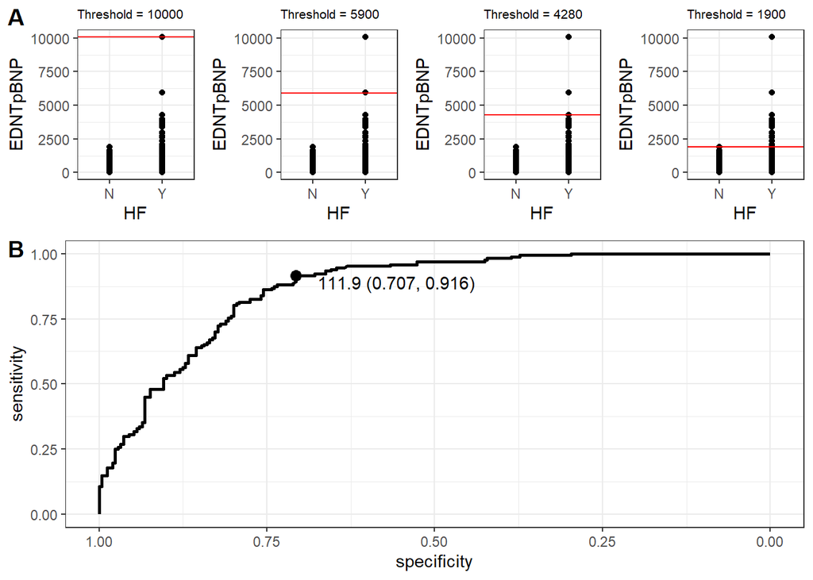

| Threshold cutoff= 10090 | Threshold cutoff= 10090 | Threshold cutoff= 10090 proBNP Y | Threshold cutoff= 10090 proBNP N |
| --- | --- | --- | --- |
| HF | Y | 1 | 166 |
|  | N | 0 | 249 |

| Threshold cutoff= 5920 | Threshold cutoff= 5920 | Threshold cutoff= 5920 proBNP Y | Threshold cutoff= 5920 proBNP N |
| --- | --- | --- | --- |
| HF | Y | 2 | 165 |
|  | N | 0 | 249 |

| Threshold cutoff= 4280 | Threshold cutoff= 4280 | Threshold cutoff= 4280 proBNP Y | Threshold cutoff= 4280 proBNP N |
| --- | --- | --- | --- |
| HF | Y | 3 | 164 |
|  | N | 0 | 249 |

| Threshold cutoff= 1926 | Threshold cutoff= 1926 | Threshold cutoff= 1926 proBNP Y | Threshold cutoff= 1926 proBNP N |
| --- | --- | --- | --- |
| HF | Y | 19 | 148 |
|  | N | 1 | 248 |

```r
## Load data important to detect dates
dat = read.xlsx("../Data/proBNP.xlsx", sheet = 1, detectDates = T)
## Calculate age (round-down to nearest year). -- Date.ofBirth wasn't detected as a date on import
dat$Age <- as.numeric(floor((dat$Baseline_Date - as.Date(dat$Date.of.Birth, "%d/%m/%Y")) /365.25))

## filter out missing data
# unsure what -1 is...
dat = dat %>% filter(EDNTpBNP > -1 & !is.na(GSDia1HF_New_At))

t.size = 8

p1<-ggplot(dat, aes(x=GSDia1HF_New_At, y= EDNTpBNP )) + geom_point() + geom_hline(yintercept = 10090, color='red') + theme_bw() + xlab("HF") +
  ggtitle("Threshold = 10000")+ theme(plot.title = element_text(size = t.size))
p2<-ggplot(dat, aes(x=GSDia1HF_New_At, y= EDNTpBNP )) + geom_point() + geom_hline(yintercept = 5920, color= 'red') +theme_bw()+ xlab("HF")+
  ggtitle("Threshold = 5900")+ theme(plot.title = element_text(size = t.size))
p3<-ggplot(dat, aes(x=GSDia1HF_New_At, y= EDNTpBNP )) + geom_point() + geom_hline(yintercept = 4280, color= 'red') +theme_bw()+ xlab("HF")+
  ggtitle("Threshold = 4280")+ theme(plot.title = element_text(size = t.size))
p4<-ggplot(dat, aes(x=GSDia1HF_New_At, y= EDNTpBNP )) + geom_point() + geom_hline(yintercept = 1926, color= 'red') +theme_bw()+ xlab("HF")+
  ggtitle("Threshold = 1900")+ theme(plot.title = element_text(size = t.size))

roc1=roc(dat$GSDia1HF_New_At, dat$EDNTpBNP)
youden= coords(roc1, best.method = "youden", 'best') %>% mutate(label=paste(round(threshold,3), " (", round(specificity,3), ", ", round(sensitivity,3), ")", sep=""))
p5<-ggroc(roc1, size=1) + theme_bw() +
  geom_point(data=youden, aes(x=specificity, y=sensitivity), size=3) +
  geom_text(data=youden, aes(x=specificity, y=sensitivity, label = label), nudge_x= .15, nudge_y = -.025)

top <- plot_grid(p1,p2,p3,p4, nrow=1)
plot_grid(top, p5, nrow=2, rel_heights = c(1,1.5), labels=LETTERS[1:2])
```

[figure not shown]

```r
dat <- read.xlsx("../Data/ROCdata.xlsx") # only one sheet no need to specify

rocA=roc(dat$Death.at.1.yr,dat$Marker.A)
rocB=roc(dat$Death.at.1.yr,dat$Marker.B)
```

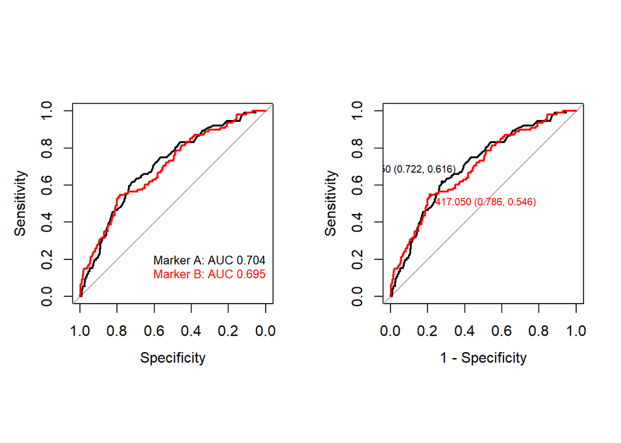

```r
par(mfrow=c(1,2), mar=c(4,4,.1,.1), pty='s')
plot(rocA)
lines(rocB, col='red')
text(0.3,.2,paste("Marker A: AUC", round(auc(rocA),3)), cex=.8)
text(0.3,.125,paste("Marker B: AUC", round(auc(rocB),3)), col='red', cex=.8)

plot(rocA,print.thres="best", print.thres.best.method="youden", legacy.axes = TRUE, print.thres.adj=c(.85,-1.25), print.thres.cex=.7, pty='s')
plot(rocB,print.thres="best", print.thres.best.method="youden", print.thres.col='red',  add=T, col='red', legacy.axes = TRUE, title= "Threshold for best model (Youden's method)", print.thres.cex=.7, pty='s')
```

# Logistic Regression

Logistic regression is a method used to model binary outcomes. In R logistic regression is a generalised linear model and can be implemented with the `glm()` function. The `glm()` funciton has many types of models, to use logistic regression the `family` options should be set to `'binomial'` (e.g. `glm(response variable ~ predictor variables,family='binomial', data=df)`).

```r
data("PimaIndiansDiabetes2")
Diabetes<- na.omit(PimaIndiansDiabetes2) # remove missing data
#levels(Diabetes$diabetes) <- 0:1 # relabel neg and pos to 0 and 1

## Fitting logistic regression predicted by all variables
model1 <- glm (diabetes~., data=Diabetes, family = 'binomial')
## not the period tells R to use all columns other than diabetes. This is the same as
##  glm(diabetes ~ pregnant + glucose + pressure + triceps + insulin + mass + pedigree + age ,data=Diabetes, family = 'binomial')

summary(model1)
```

```
Call:
glm(formula = diabetes ~ ., family = "binomial", data = Diabetes)

Deviance Residuals:
    Min       1Q   Median       3Q      Max
-2.7823  -0.6603  -0.3642   0.6409   2.5612

Coefficients:
              Estimate Std. Error z value Pr(>|z|)
(Intercept) -1.004e+01  1.218e+00  -8.246  < 2e-16 ***
pregnant     8.216e-02  5.543e-02   1.482  0.13825
glucose      3.827e-02  5.768e-03   6.635 3.24e-11 ***
pressure    -1.420e-03  1.183e-02  -0.120  0.90446
triceps      1.122e-02  1.708e-02   0.657  0.51128
insulin     -8.253e-04  1.306e-03  -0.632  0.52757
mass         7.054e-02  2.734e-02   2.580  0.00989 **
pedigree     1.141e+00  4.274e-01   2.669  0.00760 **
age          3.395e-02  1.838e-02   1.847  0.06474 .
---
Signif. codes:  0 '***' 0.001 '**' 0.01 '*' 0.05 '.' 0.1 ' ' 1

(Dispersion parameter for binomial family taken to be 1)

    Null deviance: 498.10  on 391  degrees of freedom
Residual deviance: 344.02  on 383  degrees of freedom
AIC: 362.02

Number of Fisher Scoring iterations: 5
```